# Probability and Statistics

# Lab Assignment 1: Naive Bayes Classifier

## Work breakdown

- *Nazar Mykhailyshchuk*: Bayes classifier implementation
- *Nikita Lenyk*: Data preprocessing, parametes comparison experiments
- *Anastasiya Shopska*: Data Visualisation

## Package Installation

```r
options(repos = c(CRAN = "https://cran.rstudio.com/"))
install.packages(c("readr", "stringi", "tokenizers", "SnowballC", "textstem", "tidyverse", "tidytext", "ggplot2", "wordcloud", "RColorBrewer", "gridExtra", "tidyr"))
```

## Setup

```r
library(readr)
library(textstem)
library(stringi)
library(tokenizers)
library(SnowballC)
library(tidyverse)
library(tidytext)
library(ggplot2)
library(wordcloud)
library(RColorBrewer)
library(gridExtra)
library(tidyr)
```

## Helper functions for text preprocessing

```r
# Remove stopwords from a vector of tokens (preserving order and duplicates)
remove_stopwords_from_tokens <- function(tokens, stopwords_list) {
  tokens[!tokens %in% stopwords_list]
}

# Apply stemming to tokens if they exist
apply_stemming_to_tokens <- function(tokens) {
  if (length(tokens) > 0) {
    SnowballC::wordStem(tokens, language = "english")
  } else {
    tokens
  }
}

# Apply lemmatization to tokens if they exist
apply_lemmatization_to_tokens <- function(tokens) {
  if (length(tokens) > 0) {
    textstem::lemmatize_words(tokens)
  } else {
    tokens
  }
}

# Generate word n-grams from tokens
generate_ngrams_from_tokens <- function(tokens, n) {
  if (length(tokens) >= n) {
    sapply(seq_len(length(tokens) - n + 1), function(i) {
      paste(tokens[i:(i + n - 1)], collapse = "_")
    })
  } else {
    character(0)
  }
}
```

## Text Preprocessing Pipeline

```r
#' Build Text Preprocessing Pipeline for SMS Spam Classification
#'
#' @param texts Character vector of text messages to preprocess
#' @param do_stem Apply stemming (default: FALSE)
#' @param do_lemma Apply lemmatization (default: FALSE)
#' @param remove_stopwords Remove stop words (default: TRUE)
#' @param stopwords_list Custom stop words list (default: NULL)
#' @param ngram N-gram size: 1=unigrams, 2=bigrams, etc. (default: 1)
#' @param tokenize_special Tokenize emails/phones/URLs as special tokens (default: TRUE)
#' @param vocabulary Pre-defined vocabulary (for test data). If NULL, builds vocabulary from texts (for train data)
#'
#' @return List with dtm (matrix), vocabulary, and preprocessing_info
build_preprocessing_pipeline <- function(texts,
                                         do_stem = FALSE,
                                         do_lemma = FALSE,
                                         remove_stopwords = TRUE,
                                         stopwords_list = NULL,
                                         ngram = 1,
                                         tokenize_special = TRUE,
                                         vocabulary = NULL) {
  if (!is.character(texts) || length(texts) == 0) {
    stop("texts must be a non-empty character vector")
  }

  if (!is.numeric(ngram) || length(ngram) != 1 || ngram < 1 || ngram != as.integer(ngram)) {
    stop("ngram must be a single positive integer")
  }

  if (do_stem && do_lemma) {
    warning("Both stemming and lemmatization enabled. Using lemmatization only (recommended).")
    do_stem <- FALSE
  }

  preprocessing_info <- list(
    do_stem = do_stem,
    do_lemma = do_lemma,
    remove_stopwords = remove_stopwords,
    custom_stopwords = !is.null(stopwords_list),
    ngram = ngram,
    tokenize_special = tokenize_special,
    original_length = length(texts)
  )

  # Step 1: Text cleaning and normalization
  clean_texts <- stringi::stri_trans_tolower(texts)

  if (tokenize_special) {
    # Replace special patterns with tokens
    clean_texts <- stringi::stri_replace_all_regex(clean_texts, "\\b[a-z0-9._%+-]+@[a-z0-9.-]+\\.[a-z]{2,}\\b", " EMAIL ")
    clean_texts <- stringi::stri_replace_all_regex(clean_texts, "\\bhttps?://\\S+\\b", " URL ")
    clean_texts <- stringi::stri_replace_all_regex(clean_texts, "\\b\\d{3}[-.]?\\d{3}[-.]?\\d{4}\\b", " PHONE ")
    clean_texts <- stringi::stri_replace_all_regex(clean_texts, "\\$\\d+(?:\\.\\d{2})?", " MONEY ")
    clean_texts <- stringi::stri_replace_all_regex(clean_texts, "\\b\\d{5,}\\b", " LONGNUM ")
    clean_texts <- stringi::stri_replace_all_regex(clean_texts, "[^a-z\\s]", " ")
    clean_texts <- stringi::stri_replace_all_regex(clean_texts, "\\s+", " ")
    clean_texts <- stringi::stri_trim_both(clean_texts)
  } else {
    # Standard cleaning
    clean_texts <- stringi::stri_replace_all_regex(clean_texts, "[^a-z\\s]", " ")
    clean_texts <- stringi::stri_replace_all_regex(clean_texts, "\\s+", " ")
    clean_texts <- stringi::stri_trim_both(clean_texts)
  }

  # Step 2: Tokenization
  tokens_list <- tokenizers::tokenize_words(clean_texts, lowercase = FALSE, strip_punct = FALSE)

  # Step 3: Stop words removal
  if (remove_stopwords) {
    if (is.null(stopwords_list)) {
      stopwords_list <- readLines("data/stop_words.txt", warn = FALSE)
    }

    tokens_list <- lapply(tokens_list, remove_stopwords_from_tokens, stopwords_list)
  }

  # Step 4: Stemming
  if (do_stem) {
    if (!requireNamespace("SnowballC", quietly = TRUE)) {
      warning("SnowballC package not available. Skipping stemming.")
    } else {
      tokens_list <- lapply(tokens_list, apply_stemming_to_tokens)
    }
  }

  # Step 5: Lemmatization
  if (do_lemma) {
    if (!requireNamespace("textstem", quietly = TRUE)) {
      warning("textstem package not available. Skipping lemmatization.")
    } else {
      tokens_list <- lapply(tokens_list, apply_lemmatization_to_tokens)
    }
  }
  # Step 6: N-gram generation
  if (ngram == 1) {
    ngram_tokens <- tokens_list
  } else {
    ngram_tokens <- lapply(tokens_list, generate_ngrams_from_tokens, ngram)
  }

  # Step 7: Build vocabulary and create DTM
  # Count term frequencies across all documents
  all_terms <- unlist(ngram_tokens)

  # Use provided vocabulary (for test data) or build from current texts (for train data)
  if (is.null(vocabulary)) {
    term_freq <- table(all_terms)
    vocabulary <- sort(names(term_freq))
  }

  # Create Document-Term Matrix using base R
  # Initialize empty matrix
  dtm <- matrix(0,
    nrow = length(ngram_tokens),
    ncol = length(vocabulary),
    dimnames = list(
      docs = paste0("doc", seq_along(ngram_tokens)),
      terms = vocabulary
    )
  )

  # Fill the matrix
  for (doc_idx in seq_along(ngram_tokens)) {
    doc_terms <- ngram_tokens[[doc_idx]]

    # Keep only terms that are in vocabulary
    doc_terms_in_vocab <- doc_terms[doc_terms %in% vocabulary]

    if (length(doc_terms_in_vocab) > 0) {
      # Count term frequencies for this document
      doc_term_counts <- table(doc_terms_in_vocab)

      # Update the matrix for this document
      for (term in names(doc_term_counts)) {
        dtm[doc_idx, term] <- doc_term_counts[[term]]
      }
    }
  }

  # Update preprocessing info with final statistics
  preprocessing_info$final_vocab_size <- length(vocabulary)
  preprocessing_info$final_doc_count <- nrow(dtm)
  preprocessing_info$dtm_sparsity <- 1 - (sum(dtm != 0) / (nrow(dtm) * ncol(dtm)))

  return(list(
    dtm = dtm,
    vocabulary = vocabulary,
    preprocessing_info = preprocessing_info
  ))
}
```

## Visualisation of data

### Visualisation of document term matrix and vocabulary

```r
train_data <- read_csv("data/4-spam/train.csv", show_col_types = FALSE)

train_preprocessed <- build_preprocessing_pipeline(
  texts = train_data$Message,
  do_stem = FALSE,
  do_lemma = TRUE,
  remove_stopwords = TRUE,
  stopwords_list = NULL,
  ngram = 1, # unigrams, bigrams=2, trigrams=3
  tokenize_special = TRUE,
  vocabulary = NULL
)

dtm <- train_preprocessed$dtm
rownames(dtm) <- paste0("train_", seq_len(nrow(dtm)))


term_freq <- colSums(dtm)
term_freq_sorted <- sort(term_freq, decreasing = TRUE)

top_terms_table <- data.frame(
  term = names(term_freq_sorted),
  freq = as.integer(term_freq_sorted)
)[1:10, ]



top_terms <- top_terms_table$term
dtm_top <- dtm[, top_terms]
```

### DTM

```r
dtm_top[1:5, ]
```

```
##          terms
## docs      u call get will s go now t good can
##   train_1 0    0   1    0 0  1   0 0    0   0
##   train_2 1    0   0    0 0  0   0 0    0   0
##   train_3 0    0   0    0 2  0   0 1    0   0
##   train_4 2    0   0    0 0  0   0 0    0   0
##   train_5 0    0   0    0 0  1   0 1    0   0
```

### Top terms by frequency

```r
top_terms_table
```

```
##    term freq
## 1     u  936
## 2  call  543
## 3   get  543
## 4  will  525
## 5     s  464
## 6    go  445
## 7   now  406
## 8     t  395
## 9  good  367
## 10  can  359
```

### Create word counts by class for visualization

```r
word_counts <- data.frame()

for (class_label in unique(train_data$Category)) {
  class_indices <- which(train_data$Category == class_label)
  class_word_counts <- colSums(dtm[class_indices, , drop = FALSE])
  class_df <- data.frame(
    label = class_label,
    word = names(class_word_counts),
    n = as.numeric(class_word_counts),
    stringsAsFactors = FALSE
  )

  class_df <- class_df[class_df$n > 0, ]
  word_counts <- rbind(word_counts, class_df)
}

word_counts <- word_counts %>%
  arrange(label, desc(n))
```

### Word frequency visualisations histogram and wordcloud

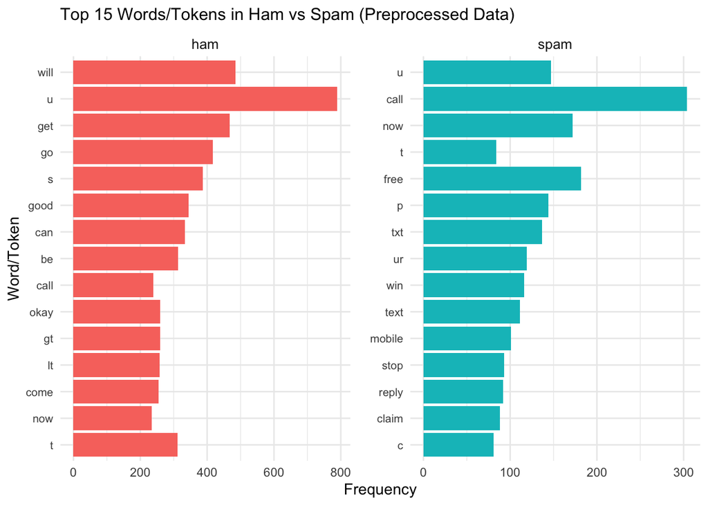

```r
top_words_by_class <- word_counts %>%
  group_by(label) %>%
  top_n(15, n) %>%
  ungroup()

top_words_by_class %>%
  ggplot(aes(x = reorder(word, n), y = n, fill = label)) +
  geom_col(show.legend = FALSE) +
  facet_wrap(~label, scales = "free") +
  coord_flip() +
  labs(
    title = "Top 15 Words/Tokens in Ham vs Spam (Preprocessed Data)",
    x = "Word/Token",
    y = "Frequency"
  ) +
  theme_minimal() +
  theme(
    axis.text.y = element_text(size = 8),
    plot.title = element_text(size = 12),
    strip.text = element_text(size = 10),
    panel.spacing = unit(0.5, "cm")
  )
```

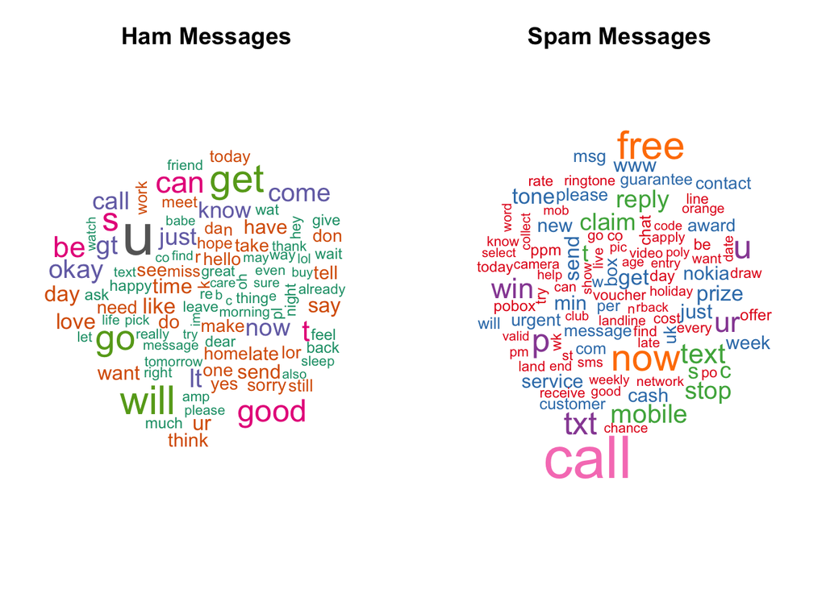

```r
regular_words <- word_counts %>%
  filter(!word %in% c("email", "url", "phone", "money", "longnum"))

ham_words <- subset(regular_words, label == "ham")
spam_words <- subset(regular_words, label == "spam")

par(mfrow = c(1, 2), mar = c(0, 0, 3, 0))

wordcloud(
  words = ham_words$word,
  freq = ham_words$n,
  min.freq = 5,
  max.words = 100,
  scale = c(3, 0.5),
  colors = brewer.pal(8, "Dark2")
)
title("Ham Messages", cex.main = 1.2)

wordcloud(
  words = spam_words$word,
  freq = spam_words$n,
  min.freq = 5,
  max.words = 100,
  scale = c(3, 0.5),
  colors = brewer.pal(8, "Set1")
)
title("Spam Messages", cex.main = 1.2)
```

```r
par(mfrow = c(1, 1), mar = c(5.1, 4.1, 4.1, 2.1))
```

## Classifier implementation

```r
naiveBayes <- setRefClass("naiveBayes",
  fields = list(
    model = "list",
    vocabulary = "character",
    preprocessing_params = "list"
  ),
  methods = list(
    fit = function(X, y, laplace = 1, do_stem = FALSE, do_lemma = TRUE, remove_stopwords = TRUE, ngram = 1, tokenize_special = TRUE) {
      train_preprocessed <- build_preprocessing_pipeline(
        texts = X,
        do_stem = do_stem,
        do_lemma = do_lemma,
        remove_stopwords = remove_stopwords,
        stopwords_list = NULL,
        ngram = ngram,
        tokenize_special = tokenize_special,
        vocabulary = NULL
      )

      dtm <- train_preprocessed$dtm
      vocabulary <<- train_preprocessed$vocabulary
      # Store preprocessing parameters from pipeline
      preprocessing_params <<- train_preprocessed$preprocessing_info

      # Train multinomial Naive Bayes
      labels <- as.character(y)
      classes <- sort(unique(labels))
      n_docs <- nrow(dtm)
      n_terms <- ncol(dtm)

      # calculate priority probabilities
      class_counts <- table(labels)
      class_priors <- class_counts / n_docs
      log_priors <- log(class_priors) # avoid overflow

      # word probability
      term_counts_by_class <- matrix(0,
        nrow = length(classes), ncol = n_terms,
        dimnames = list(classes, colnames(dtm))
      )
      for (cls in classes) {
        rows_in_class <- which(labels == cls)
        term_counts_by_class[cls, ] <- colSums(dtm[rows_in_class, , drop = FALSE])
      }

      class_total_terms <- rowSums(term_counts_by_class)

      # laplace and log
      numerator <- term_counts_by_class + laplace
      denominator <- class_total_terms + laplace * n_terms

      log_likelihoods <- log(t(numerator / denominator))

      # Store model
      model <<- list(
        classes = classes,
        log_priors = log_priors,
        log_likelihoods = log_likelihoods,
        vocabulary = colnames(dtm)
      )
    },
    predict = function(message) {
      if (is.null(model) || length(model) == 0) {
        stop("Model not trained. Please call fit() first.")
      }
      test_preprocessed <- build_preprocessing_pipeline(
        texts = message,
        do_stem = preprocessing_params$do_stem,
        do_lemma = preprocessing_params$do_lemma,
        remove_stopwords = preprocessing_params$remove_stopwords,
        stopwords_list = NULL,
        ngram = preprocessing_params$ngram,
        tokenize_special = preprocessing_params$tokenize_special,
        vocabulary = vocabulary
      )

      dtm_new <- test_preprocessed$dtm

      vocab <- model$vocabulary
      dtm_aligned <- matrix(0,
        nrow = nrow(dtm_new), ncol = length(vocab),
        dimnames = list(rownames(dtm_new), vocab)
      )
      common_cols <- intersect(colnames(dtm_new), vocab)
      if (length(common_cols) > 0) {
        dtm_aligned[, common_cols] <- dtm_new[, common_cols]
      }

      # Calculate scores
      # dtm_aligned: n_docs x n_vocab, log_likelihoods: n_vocab x n_classes
      scores_mat <- dtm_aligned %*% model$log_likelihoods
      scores_mat <- sweep(scores_mat, 2, model$log_priors, "+")

      # Get winning class
      best_class_idx <- max.col(scores_mat, ties.method = "first")
      predictions <- model$classes[best_class_idx]
      return(predictions)
    },
    score = function(X_test, y_test) {
      if (is.null(model) || length(model) == 0) {
        stop("Model not trained. Please call fit() first.")
      }
      # Get predictions for test data
      predictions <- sapply(X_test, function(msg) predict(msg))

      # Calculate accuracy
      correct_predictions <- sum(predictions == y_test)
      total_predictions <- length(y_test)
      accuracy <- correct_predictions / total_predictions

      # Create confusion matrix
      classes <- sort(unique(c(predictions, y_test)))
      confusion_matrix <- matrix(0, nrow = length(classes), ncol = length(classes))
      rownames(confusion_matrix) <- paste("Predicted", classes)
      colnames(confusion_matrix) <- paste("Actual", classes)

      for (i in seq_along(predictions)) {
        pred_idx <- which(classes == predictions[i])
        actual_idx <- which(classes == y_test[i])
        confusion_matrix[pred_idx, actual_idx] <- confusion_matrix[pred_idx, actual_idx] + 1
      }

      # Calculate precision, recall, F1 for each class
      results <- data.frame(
        Class = classes,
        Precision = numeric(length(classes)),
        Recall = numeric(length(classes)),
        F1_Score = numeric(length(classes)),
        stringsAsFactors = FALSE
      )

      for (i in seq_along(classes)) {
        cls <- classes[i]
        tp <- confusion_matrix[i, i] # true positives
        fp <- sum(confusion_matrix[i, ]) - tp # false positives
        fn <- sum(confusion_matrix[, i]) - tp # false negatives

        precision <- if (tp + fp == 0) 0 else tp / (tp + fp)
        recall <- if (tp + fn == 0) 0 else tp / (tp + fn)
        f1 <- if (precision + recall == 0) 0 else 2 * (precision * recall) / (precision + recall)

        results[i, "Precision"] <- round(precision, 4)
        results[i, "Recall"] <- round(recall, 4)
        results[i, "F1_Score"] <- round(f1, 4)
      }

      # Return comprehensive results
      return(list(
        accuracy = round(accuracy, 4),
        correct = correct_predictions,
        total = total_predictions,
        confusion_matrix = confusion_matrix,
        class_metrics = results
      ))
    }
  )
)

model <- naiveBayes()
```

## Example Usage (Predicting Spam vs Ham) for single message and batch of messages

```r
train_data <- read_csv("data/4-spam/train.csv", show_col_types = FALSE)
model <- naiveBayes()
model$fit(X = train_data$Message, y = train_data$Category)

test_message <- "Free money!!! Click here to claim your prize."
prediction <- model$predict(test_message)
print(paste("Prediction:", prediction))
```

```
## [1] "Prediction: spam"
```

```r
test_data <- read_csv("data/4-spam/test.csv", show_col_types = FALSE)
test_predictions <- sapply(test_data$Message, function(msg) model$predict(msg))
print(paste("First 5 predictions:", paste(test_predictions[1:5], collapse = ", ")))
```

```
## [1] "First 5 predictions: ham, ham, ham, ham, ham"
```

## Parameter Comparison Experiments

### Testing Different Preprocessing Parameters

```r
# Load test data for evaluation
test_data <- read_csv("data/4-spam/test.csv", show_col_types = FALSE)

experiments <- list(
  "Baseline (Lemma + No Stopwords + Unigrams + Special)" = list(
    do_stem = FALSE, do_lemma = TRUE, remove_stopwords = FALSE,
    ngram = 1, tokenize_special = TRUE
  ),
  "Stemming + Stopwords + Unigrams + Special" = list(
    do_stem = TRUE, do_lemma = FALSE, remove_stopwords = TRUE,
    ngram = 1, tokenize_special = TRUE
  ),
  "Lemma + Stopwords + Bigrams + Special" = list(
    do_stem = FALSE, do_lemma = TRUE, remove_stopwords = TRUE,
    ngram = 2, tokenize_special = TRUE
  ),
  "Lemma + Stopwords + Trigrams + Special" = list(
    do_stem = FALSE, do_lemma = TRUE, remove_stopwords = TRUE,
    ngram = 3, tokenize_special = TRUE
  ),
  "Lemma + Stopwords + Unigrams + No Special" = list(
    do_stem = FALSE, do_lemma = TRUE, remove_stopwords = TRUE,
    ngram = 1, tokenize_special = FALSE
  )
)

experiment_results <- list()
confusion_matrices <- list()

# Run experiments
for (exp_name in names(experiments)) {
  params <- experiments[[exp_name]]
  model_exp <- naiveBayes()
  model_exp$fit(
    X = train_data$Message,
    y = train_data$Category,
    do_stem = params$do_stem,
    do_lemma = params$do_lemma,
    remove_stopwords = params$remove_stopwords,
    ngram = params$ngram,
    tokenize_special = params$tokenize_special
  )
  # Evaluate on test data
  results <- model_exp$score(test_data$Message, test_data$Category)
  experiment_results[[exp_name]] <- results
  confusion_matrices[[exp_name]] <- results$confusion_matrix
}
```

```r
comparison_data <- data.frame(
  Experiment = names(experiment_results),
  Accuracy = sapply(experiment_results, function(x) x$accuracy),
  Correct = sapply(experiment_results, function(x) x$correct),
  Total = sapply(experiment_results, function(x) x$total),
  SPAM_Precision = sapply(experiment_results, function(x) {
    spam_row <- which(x$class_metrics$Class == "spam")
    if (length(spam_row) > 0) x$class_metrics$Precision[spam_row] else 0
  }),
  SPAM_Recall = sapply(experiment_results, function(x) {
    spam_row <- which(x$class_metrics$Class == "spam")
    if (length(spam_row) > 0) x$class_metrics$Recall[spam_row] else 0
  }),
  SPAM_F1 = sapply(experiment_results, function(x) {
    spam_row <- which(x$class_metrics$Class == "spam")
    if (length(spam_row) > 0) x$class_metrics$F1_Score[spam_row] else 0
  }),
  HAM_Precision = sapply(experiment_results, function(x) {
    ham_row <- which(x$class_metrics$Class == "ham")
    if (length(ham_row) > 0) x$class_metrics$Precision[ham_row] else 0
  }),
  HAM_Recall = sapply(experiment_results, function(x) {
    ham_row <- which(x$class_metrics$Class == "ham")
    if (length(ham_row) > 0) x$class_metrics$Recall[ham_row] else 0
  }),
  HAM_F1 = sapply(experiment_results, function(x) {
    ham_row <- which(x$class_metrics$Class == "ham")
    if (length(ham_row) > 0) x$class_metrics$F1_Score[ham_row] else 0
  }),
  stringsAsFactors = FALSE
)
```

```r
# Detailed SPAM metrics table
spam_metrics <- data.frame(
  Configuration = c("Baseline", "Stemming", "Bigrams", "Trigrams", "No Special"),
  Precision = round(comparison_data$SPAM_Precision, 3),
  Recall = round(comparison_data$SPAM_Recall, 3),
  F1_Score = round(comparison_data$SPAM_F1, 3)
)
print("SPAM Detection Performance:")
```

```
## [1] "SPAM Detection Performance:"
```

```r
spam_metrics
```

```
##   Configuration Precision Recall F1_Score
## 1      Baseline     0.943  0.949    0.946
## 2      Stemming     0.932  0.949    0.940
## 3       Bigrams     0.959  0.886    0.921
## 4      Trigrams     1.000  0.671    0.803
## 5    No Special     0.938  0.956    0.947
```

```r
# Detailed HAM metrics table
ham_metrics <- data.frame(
  Configuration = c("Baseline", "Stemming", "Bigrams", "Trigrams", "No Special"),
  Precision = round(comparison_data$HAM_Precision, 3),
  Recall = round(comparison_data$HAM_Recall, 3),
  F1_Score = round(comparison_data$HAM_F1, 3)
)
print("HAM Detection Performance:")
```

```
## [1] "HAM Detection Performance:"
```

```r
ham_metrics
```

```
##   Configuration Precision Recall F1_Score
## 1      Baseline     0.993  0.992    0.992
## 2      Stemming     0.993  0.990    0.991
## 3       Bigrams     0.984  0.994    0.989
## 4      Trigrams     0.954  1.000    0.976
## 5    No Special     0.994  0.991    0.992
```

### 1. Acсuracy Comparison Bar Plot

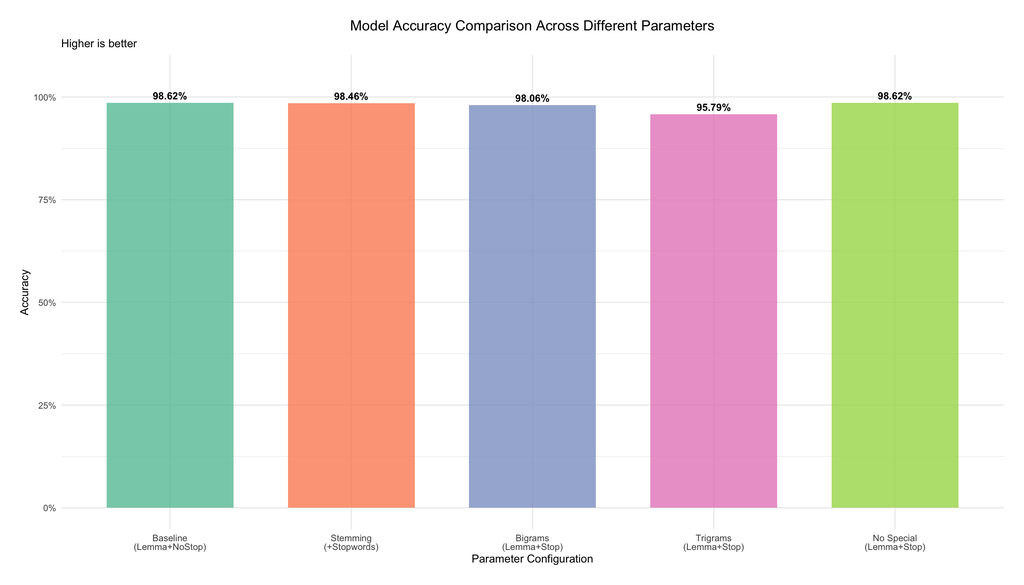

```r
# Prepare data for plotting with shorter labels
plot_data <- comparison_data
plot_data$Short_Label <- c("Baseline\n(Lemma+NoStop)", "Stemming\n(+Stopwords)", "Bigrams\n(Lemma+Stop)", "Trigrams\n(Lemma+Stop)", "No Special\n(Lemma+Stop)")
plot_data$Short_Label <- factor(plot_data$Short_Label, levels = plot_data$Short_Label)

ggplot(plot_data, aes(x = Short_Label, y = Accuracy, fill = Short_Label)) +
  geom_col(alpha = 0.8, width = 0.7) +
  geom_text(aes(label = paste0(round(Accuracy * 100, 2), "%")),
    vjust = -0.5, size = 3.5, fontface = "bold"
  ) +
  scale_y_continuous(limits = c(0, 1.05), labels = scales::percent) +
  scale_fill_brewer(type = "qual", palette = "Set2") +
  theme_minimal() +
  theme(
    axis.text.x = element_text(size = 9, lineheight = 0.8),
    legend.position = "none",
    plot.title = element_text(size = 14, hjust = 0.5),
    axis.title = element_text(size = 11),
    plot.margin = margin(20, 20, 20, 20)
  ) +
  labs(
    title = "Model Accuracy Comparison Across Different Parameters",
    subtitle = "Higher is better",
    x = "Parameter Configuration",
    y = "Accuracy"
  )
```

### 2. Detailed Metrics Comparison

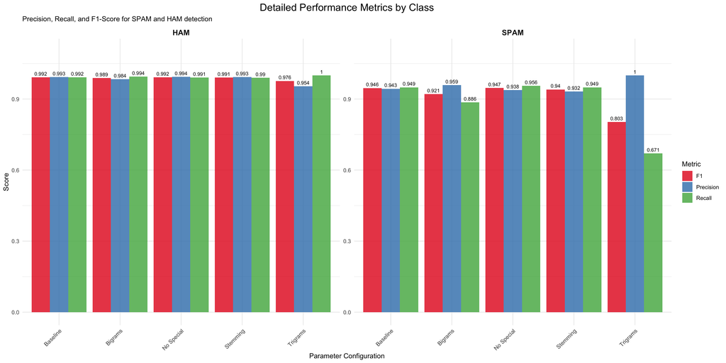

```r
# Add shorter labels for better readability
comparison_data_short <- comparison_data
comparison_data_short$Short_Label <- c("Baseline", "Stemming", "Bigrams", "Trigrams", "No Special")

metrics_long <- comparison_data_short %>%
  select(
    Short_Label, SPAM_Precision, SPAM_Recall, SPAM_F1,
    HAM_Precision, HAM_Recall, HAM_F1
  ) %>%
  pivot_longer(cols = -Short_Label, names_to = "Metric", values_to = "Value") %>%
  separate(Metric, into = c("Class", "Metric_Type"), sep = "_")

ggplot(metrics_long, aes(x = Short_Label, y = Value, fill = Metric_Type)) +
  geom_col(position = "dodge", alpha = 0.8) +
  facet_wrap(~Class, ncol = 2, scales = "free") +
  geom_text(aes(label = round(Value, 3)),
    position = position_dodge(width = 0.9),
    vjust = -0.5, size = 2.8
  ) +
  scale_y_continuous(limits = c(0, 1.1)) +
  scale_fill_brewer(type = "qual", palette = "Set1") +
  theme_minimal() +
  theme(
    axis.text.x = element_text(angle = 45, hjust = 1, size = 9),
    strip.text = element_text(size = 12, face = "bold"),
    plot.title = element_text(size = 16, hjust = 0.5)
  ) +
  labs(
    title = "Detailed Performance Metrics by Class",
    subtitle = "Precision, Recall, and F1-Score for SPAM and HAM detection",
    x = "Parameter Configuration",
    y = "Score",
    fill = "Metric"
  )
```

### 3. Confusion Matrices Visualization

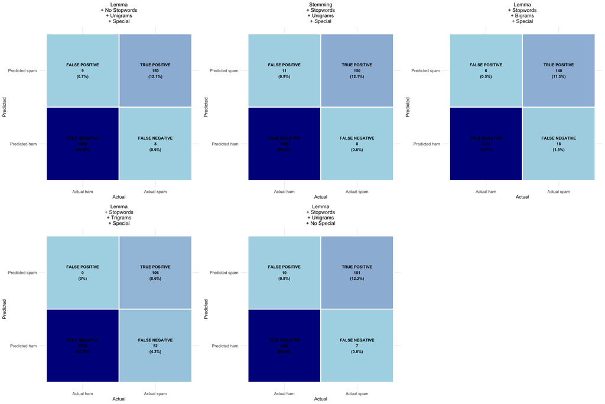

```r
# Create a function to plot confusion matrix with TP/TN/FP/FN labels
plot_confusion_matrix <- function(cm, title) {
  # Convert to data frame for ggplot
  cm_df <- expand.grid(
    Predicted = rownames(cm),
    Actual = colnames(cm)
  )
  cm_df$Count <- as.vector(cm)

  # Calculate percentages
  total <- sum(cm)
  cm_df$Percentage <- cm_df$Count / total * 100

  # Add TP/TN/FP/FN labels
  cm_df$Label <- ""

  # Extract class names from Predicted and Actual columns (remove "Predicted " and "Actual " prefixes)
  cm_df$pred_class <- gsub("Predicted ", "", cm_df$Predicted)
  cm_df$actual_class <- gsub("Actual ", "", cm_df$Actual)

  for (i in seq_len(nrow(cm_df))) {
    pred <- cm_df$pred_class[i]
    actual <- cm_df$actual_class[i]

    if (pred == actual) {
      if (pred == "spam") {
        cm_df$Label[i] <- "TRUE POSITIVE"
      } else {
        cm_df$Label[i] <- "TRUE NEGATIVE"
      }
    } else {
      if (pred == "spam") {
        cm_df$Label[i] <- "FALSE POSITIVE"
      } else {
        cm_df$Label[i] <- "FALSE NEGATIVE"
      }
    }
  }

  ggplot(cm_df, aes(x = Actual, y = Predicted, fill = Count)) +
    geom_tile(color = "white", size = 1) +
    geom_text(aes(label = paste0(Label, "\n", Count, "\n(", round(Percentage, 1), "%)")),
      size = 3, fontface = "bold"
    ) +
    scale_fill_gradient(low = "lightblue", high = "darkblue") +
    theme_minimal() +
    theme(
      plot.title = element_text(size = 11, hjust = 0.5),
      axis.title = element_text(size = 10),
      legend.position = "none"
    ) +
    labs(title = title, x = "Actual", y = "Predicted")
}

confusion_plots <- list()
for (i in seq_along(confusion_matrices)) {
  exp_name <- names(confusion_matrices)[i]
  short_title <- gsub("Baseline \\(|\\)", "", exp_name)
  short_title <- gsub(" \\+ ", "\n+ ", short_title)
  confusion_plots[[i]] <- plot_confusion_matrix(confusion_matrices[[i]], short_title)
}
do.call(grid.arrange, c(confusion_plots, ncol = 3))
```

### 4. Best Configuration Analysis

```r
best_accuracy_idx <- which.max(comparison_data$Accuracy)
best_config <- comparison_data[best_accuracy_idx, ]

best_summary <- data.frame(
  Metric = c("Best Configuration", "Accuracy (%)", "SPAM F1-Score", "HAM F1-Score"),
  Value = c(
    as.character(best_config$Experiment),
    paste0(round(best_config$Accuracy * 100, 2), "%"),
    round(best_config$SPAM_F1, 4),
    round(best_config$HAM_F1, 4)
  )
)
best_summary
```

```
##               Metric                                                Value
## 1 Best Configuration Baseline (Lemma + No Stopwords + Unigrams + Special)
## 2       Accuracy (%)                                               98.62%
## 3      SPAM F1-Score                                               0.9464
## 4       HAM F1-Score                                               0.9921
```

## Conclusions

### Mathematical Foundation

We implemented a Multinomial Naive Bayes classifier based on Bayes’ theorem. The mathematical foundation consists of several key components:

**1. Bayes’ Theorem:**
$$P(c|d) = \frac{P(d|c) \cdot
P(c)}{P(d)}$$

Where: - $P(c|d)$ is the posterior probability of class $c$ given document $d$ - $P(d|c)$ is the likelihood of document $d$ given class $c$ - $P(c)$ is the prior probability of class $c$ - $P(d)$ is the evidence (marginal probability of document $d$)

**2. Classification Decision Rule:**

For classification, we calculate the probability for each class: - Calculate $P(\text{spam}|d) = P(d|\text{spam}) \cdot P(\text{spam})$ - Calculate $P(\text{ham}|d) = P(d|\text{ham}) \cdot P(\text{ham})$ - If $P(\text{spam}|d) > P(\text{ham}|d)$, classify as spam, otherwise as ham

**3. Multinomial Naive Bayes Model:**

Assuming conditional independence between words (naive assumption), the likelihood becomes:
$$P(d|c) =
\prod_{i=1}^{|V|} P(w_i|c)^{n_i}$$

Where: - $|V|$ is the vocabulary size - $w_i$ is the $i$-th word in vocabulary - $n_i$ is the count of word $w_i$ in document $d$

**4. Parameter Estimation:**

**Prior Probability:**
$$P(c)
= \frac{N_c}{N}$$
Where $N_c$ is the number of documents in class $c$ and $N$ is the total number of documents.

**Word Probability with Laplace Smoothing:**
$$P(w_i|c) = \frac{\text{count}(w_i, c) +
\alpha}{\sum_{w \in V} \text{count}(w, c) + \alpha|V|}$$

Where: - $\text{count}(w_i, c)$ is the frequency of word $w_i$ in class $c$ - $\alpha$ is the smoothing parameter (Laplace smoothing, typically $\alpha = 1$) - $|V|$ is the vocabulary size

**5. Log-Space Computation:**

To avoid numerical underflow, we work in log-space:
$$\log P(c|d) \propto \log P(c) + \sum_{i=1}^{|V|}
n_i \log P(w_i|c)$$

**Final Classification in Log-Space:**

For each class, calculate the score:
$$\text{Score}(c) = \log P(c) + \sum_{i=1}^{|V|}
n_i \log P(w_i|c)$$

Then compare: - If $\text{Score}(\text{spam}) > \text{Score}(\text{ham})$, classify as spam - Otherwise, classify as ham

**Pros:** Works well with small datasets, handles high-dimensional sparse data effectively, probabilistic output.

**Cons:** Strong independence assumption (words are independent), sensitive to unstable data, bad performance with unseen word combinations in test data.

**Accuracy vs F1-Score:** Accuracy can be misleading with imbalanced datasets (For example 95% ham, 5% spam). A model predicting “all ham” would have 95% accuracy but 0% spam detection. F1-score balances precision and recall, providing better insight into performance on minority classes, which is crucial for spam detection where missing spam (false negatives) is costly.